# Human_Resources_Department

## Human Resources Department

### By Chirapa Muadchan

Source: https://toggl.com/blog/cost-of-hiring-an-employee

To hire a new employee costs around $7000 and it takes about 52 days on average to fill a position. Then, it is better to know who are likely to quit a job at the company in order to convince them not to leave.

#### Objective

- To predict employees who are more likely to leave the company

#### Data Source

https://www.kagle.com/pavansubhasht/ibm-hr-analytics-attrition-dataset

Important features of the data

- JobInvolvement
- Education
- JObSatisfaction
- PerformanceRating
- RelationshipSatisfaction
- WorkLifeBalnce

### Loading libraries

```python
import pandas as pd
import numpy as np
import seaborn as sns
import matplotlib.pyplot as plt
```

### Importing datasets

```python
employee_df = pd.read_csv('Human_Resources.csv')
```

```python
employee_df.head()
```

|  | Age | Attrition | BusinessTravel | DailyRate | Department | DistanceFromHome | Education | EducationField | EmployeeCount | EmployeeNumber | ... | RelationshipSatisfaction | StandardHours | StockOptionLevel | TotalWorkingYears | TrainingTimesLastYear | WorkLifeBalance | YearsAtCompany | YearsInCurrentRole | YearsSinceLastPromotion | YearsWithCurrManager |
| --- | --- | --- | --- | --- | --- | --- | --- | --- | --- | --- | --- | --- | --- | --- | --- | --- | --- | --- | --- | --- | --- |
| 0 | 41 | Yes | Travel_Rarely | 1102 | Sales | 1 | 2 | Life Sciences | 1 | 1 | ... | 1 | 80 | 0 | 8 | 0 | 1 | 6 | 4 | 0 | 5 |
| 1 | 49 | No | Travel_Frequently | 279 | Research & Development | 8 | 1 | Life Sciences | 1 | 2 | ... | 4 | 80 | 1 | 10 | 3 | 3 | 10 | 7 | 1 | 7 |
| 2 | 37 | Yes | Travel_Rarely | 1373 | Research & Development | 2 | 2 | Other | 1 | 4 | ... | 2 | 80 | 0 | 7 | 3 | 3 | 0 | 0 | 0 | 0 |
| 3 | 33 | No | Travel_Frequently | 1392 | Research & Development | 3 | 4 | Life Sciences | 1 | 5 | ... | 3 | 80 | 0 | 8 | 3 | 3 | 8 | 7 | 3 | 0 |
| 4 | 27 | No | Travel_Rarely | 591 | Research & Development | 2 | 1 | Medical | 1 | 7 | ... | 4 | 80 | 1 | 6 | 3 | 3 | 2 | 2 | 2 | 2 |

5 rows × 35 columns

```python
employee_df.shape
```

```
(1470, 35)
```

Data has 1470 rows and 35 columns as the following details.

```python
employee_df.info()
```

```
<class 'pandas.core.frame.DataFrame'>
RangeIndex: 1470 entries, 0 to 1469
Data columns (total 35 columns):
 #   Column                    Non-Null Count  Dtype
---  ------                    --------------  -----
 0   Age                       1470 non-null   int64
 1   Attrition                 1470 non-null   object
 2   BusinessTravel            1470 non-null   object
 3   DailyRate                 1470 non-null   int64
 4   Department                1470 non-null   object
 5   DistanceFromHome          1470 non-null   int64
 6   Education                 1470 non-null   int64
 7   EducationField            1470 non-null   object
 8   EmployeeCount             1470 non-null   int64
 9   EmployeeNumber            1470 non-null   int64
```

[output cut: 27 more lines]

```python
employee_df['Age'].mean()
```

```
36.923809523809524
```

The average age of employees is 37 years old.

### Data Visualization

```python
# Let's replace 'Attritition' , 'overtime' , 'Over18' column with integers before performing any visualizations
# Yes =1, No = 0
employee_df['Attrition'] = employee_df['Attrition'].apply(lambda x:1 if x =='Yes' else 0)
employee_df['OverTime'] = employee_df['OverTime'].apply(lambda x:1 if x =='Yes' else 0)
employee_df['Over18'] = employee_df['Over18'].apply(lambda x:1 if x =='Y' else 0)
```

```python
print(employee_df['Attrition'].unique())
print(employee_df['OverTime'].unique())
print(employee_df['Over18'].unique())
```

```
[1 0]
[1 0]
[1]
```

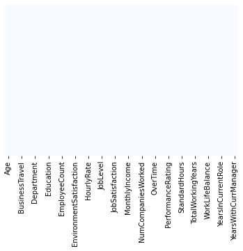

```python
# Check if there is any missing data
sns.heatmap(employee_df.isnull(), yticklabels = False, cbar = False, cmap = 'Blues')
```

There is no missing data in this dataset.

```
array([[<AxesSubplot:title={'center':'Age'}>,
        <AxesSubplot:title={'center':'Attrition'}>,
        <AxesSubplot:title={'center':'DailyRate'}>,
        <AxesSubplot:title={'center':'DistanceFromHome'}>,
        <AxesSubplot:title={'center':'Education'}>],
       [<AxesSubplot:title={'center':'EmployeeCount'}>,
        <AxesSubplot:title={'center':'EmployeeNumber'}>,
        <AxesSubplot:title={'center':'EnvironmentSatisfaction'}>,
        <AxesSubplot:title={'center':'HourlyRate'}>,
        <AxesSubplot:title={'center':'JobInvolvement'}>],
       [<AxesSubplot:title={'center':'JobLevel'}>,
        <AxesSubplot:title={'center':'JobSatisfaction'}>,
        <AxesSubplot:title={'center':'MonthlyIncome'}>,
        <AxesSubplot:title={'center':'MonthlyRate'}>,
        <AxesSubplot:title={'center':'NumCompaniesWorked'}>],
       [<AxesSubplot:title={'center':'Over18'}>,
        <AxesSubplot:title={'center':'OverTime'}>,
        <AxesSubplot:title={'center':'PercentSalaryHike'}>,
        <AxesSubplot:title={'center':'PerformanceRating'}>,
        <AxesSubplot:title={'center':'RelationshipSatisfaction'}>],
       [<AxesSubplot:title={'center':'StandardHours'}>,
        <AxesSubplot:title={'center':'StockOptionLevel'}>,
        <AxesSubplot:title={'center':'TotalWorkingYears'}>,
        <AxesSubplot:title={'center':'TrainingTimesLastYear'}>,
        <AxesSubplot:title={'center':'WorkLifeBalance'}>],
       [<AxesSubplot:title={'center':'YearsAtCompany'}>,
        <AxesSubplot:title={'center':'YearsInCurrentRole'}>,
        <AxesSubplot:title={'center':'YearsSinceLastPromotion'}>,
        <AxesSubplot:title={'center':'YearsWithCurrManager'}>,
        <AxesSubplot:>]], dtype=object)
```

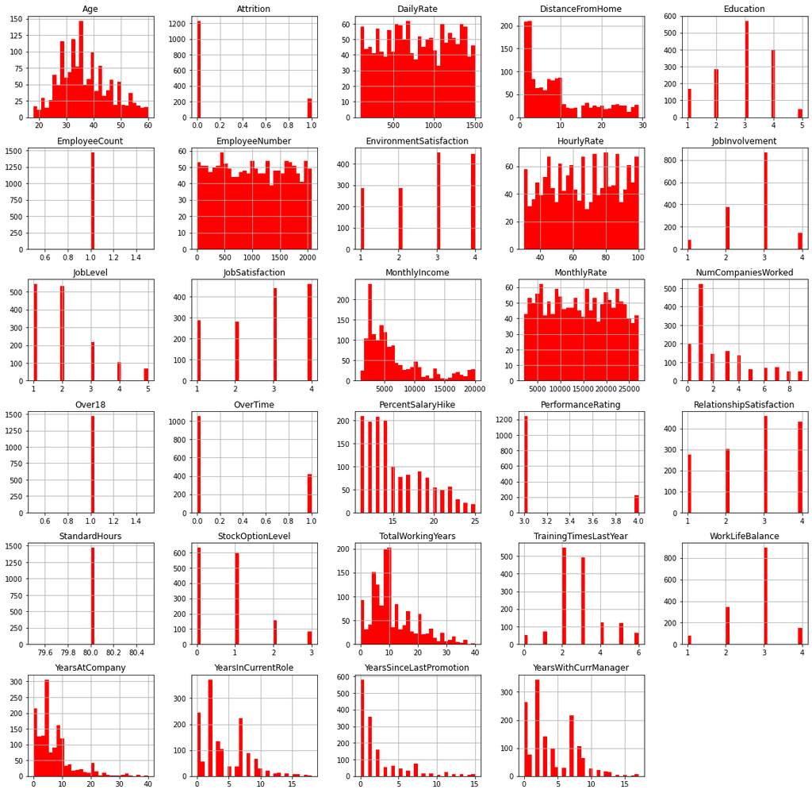

```python
employee_df.hist(bins = 30, figsize =(20,20), color ='r')
```

Above, there are insightful information we have found.

- Most of the employees are about 37 years old.
- About 16% of employees left the company.
- Most of the employees live near by the company.
- MOst of the employees work for the company for 5 years.

```python
employee_df.drop(['EmployeeCount', 'StandardHours', 'Over18', 'EmployeeNumber'], axis=1, inplace=True)
```

Above, I dropped useless variables since they are not meaningful and not different from one to other employees. There are EmployeeCount, StandardHours, Over18, and EmployeeNumber.

```python
employee_df.info()
```

```
<class 'pandas.core.frame.DataFrame'>
RangeIndex: 1470 entries, 0 to 1469
Data columns (total 31 columns):
 #   Column                    Non-Null Count  Dtype
---  ------                    --------------  -----
 0   Age                       1470 non-null   int64
 1   Attrition                 1470 non-null   int64
 2   BusinessTravel            1470 non-null   object
 3   DailyRate                 1470 non-null   int64
 4   Department                1470 non-null   object
 5   DistanceFromHome          1470 non-null   int64
 6   Education                 1470 non-null   int64
 7   EducationField            1470 non-null   object
 8   EnvironmentSatisfaction   1470 non-null   int64
 9   Gender                    1470 non-null   object
```

[output cut: 23 more lines]

```python
left_df = employee_df[employee_df['Attrition']==1]
stayed_df = employee_df[employee_df['Attrition']==0]
print('Employees who left with the company', len(left_df))
print('Employees who stayed with the company', len(stayed_df))
```

```
Employees who left with the company 237
Employees who stayed with the company 1233
```

```python
# Count the number of employees who stayed and left
# It seems that we are dealing with an imbalanced dataset
print('The number of employees who stayed is', stayed_df.shape[0])
print('The number of employees who left is', left_df.shape[0])
print('% of employees who stayed is ', round(stayed_df.shape[0]*100/(employee_df.shape[0]),2),'%'  )
print('% of employees who left is ', round(left_df.shape[0]*100/(employee_df.shape[0]),2),'%'  )
```

```
The number of employees who stayed is 1233
The number of employees who left is 237
% of employees who stayed is  83.88 %
% of employees who left is  16.12 %
```

```python
left_df.describe()
```

|  | Age | Attrition | DailyRate | DistanceFromHome | Education | EnvironmentSatisfaction | HourlyRate | JobInvolvement | JobLevel | JobSatisfaction | ... | PerformanceRating | RelationshipSatisfaction | StockOptionLevel | TotalWorkingYears | TrainingTimesLastYear | WorkLifeBalance | YearsAtCompany | YearsInCurrentRole | YearsSinceLastPromotion | YearsWithCurrManager |
| --- | --- | --- | --- | --- | --- | --- | --- | --- | --- | --- | --- | --- | --- | --- | --- | --- | --- | --- | --- | --- | --- |
| count | 237.000000 | 237.0 | 237.000000 | 237.000000 | 237.000000 | 237.000000 | 237.000000 | 237.000000 | 237.000000 | 237.000000 | ... | 237.000000 | 237.000000 | 237.000000 | 237.000000 | 237.000000 | 237.000000 | 237.000000 | 237.000000 | 237.000000 | 237.000000 |
| mean | 33.607595 | 1.0 | 750.362869 | 10.632911 | 2.839662 | 2.464135 | 65.573840 | 2.518987 | 1.637131 | 2.468354 | ... | 3.156118 | 2.599156 | 0.527426 | 8.244726 | 2.624473 | 2.658228 | 5.130802 | 2.902954 | 1.945148 | 2.852321 |
| std | 9.689350 | 0.0 | 401.899519 | 8.452525 | 1.008244 | 1.169791 | 20.099958 | 0.773405 | 0.940594 | 1.118058 | ... | 0.363735 | 1.125437 | 0.856361 | 7.169204 | 1.254784 | 0.816453 | 5.949984 | 3.174827 | 3.153077 | 3.143349 |
| min | 18.000000 | 1.0 | 103.000000 | 1.000000 | 1.000000 | 1.000000 | 31.000000 | 1.000000 | 1.000000 | 1.000000 | ... | 3.000000 | 1.000000 | 0.000000 | 0.000000 | 0.000000 | 1.000000 | 0.000000 | 0.000000 | 0.000000 | 0.000000 |
| 25% | 28.000000 | 1.0 | 408.000000 | 3.000000 | 2.000000 | 1.000000 | 50.000000 | 2.000000 | 1.000000 | 1.000000 | ... | 3.000000 | 2.000000 | 0.000000 | 3.000000 | 2.000000 | 2.000000 | 1.000000 | 0.000000 | 0.000000 | 0.000000 |
| 50% | 32.000000 | 1.0 | 699.000000 | 9.000000 | 3.000000 | 3.000000 | 66.000000 | 3.000000 | 1.000000 | 3.000000 | ... | 3.000000 | 3.000000 | 0.000000 | 7.000000 | 2.000000 | 3.000000 | 3.000000 | 2.000000 | 1.000000 | 2.000000 |
| 75% | 39.000000 | 1.0 | 1092.000000 | 17.000000 | 4.000000 | 4.000000 | 84.000000 | 3.000000 | 2.000000 | 3.000000 | ... | 3.000000 | 4.000000 | 1.000000 | 10.000000 | 3.000000 | 3.000000 | 7.000000 | 4.000000 | 2.000000 | 5.000000 |
| max | 58.000000 | 1.0 | 1496.000000 | 29.000000 | 5.000000 | 4.000000 | 100.000000 | 4.000000 | 5.000000 | 4.000000 | ... | 4.000000 | 4.000000 | 3.000000 | 40.000000 | 6.000000 | 4.000000 | 40.000000 | 15.000000 | 15.000000 | 14.000000 |

8 rows × 25 columns

```python
stayed_df.describe()
```

|  | Age | Attrition | DailyRate | DistanceFromHome | Education | EnvironmentSatisfaction | HourlyRate | JobInvolvement | JobLevel | JobSatisfaction | ... | PerformanceRating | RelationshipSatisfaction | StockOptionLevel | TotalWorkingYears | TrainingTimesLastYear | WorkLifeBalance | YearsAtCompany | YearsInCurrentRole | YearsSinceLastPromotion | YearsWithCurrManager |
| --- | --- | --- | --- | --- | --- | --- | --- | --- | --- | --- | --- | --- | --- | --- | --- | --- | --- | --- | --- | --- | --- |
| count | 1233.000000 | 1233.0 | 1233.000000 | 1233.000000 | 1233.000000 | 1233.000000 | 1233.000000 | 1233.000000 | 1233.000000 | 1233.000000 | ... | 1233.000000 | 1233.000000 | 1233.000000 | 1233.000000 | 1233.000000 | 1233.000000 | 1233.000000 | 1233.000000 | 1233.000000 | 1233.000000 |
| mean | 37.561233 | 0.0 | 812.504461 | 8.915653 | 2.927007 | 2.771290 | 65.952149 | 2.770479 | 2.145985 | 2.778589 | ... | 3.153285 | 2.733982 | 0.845093 | 11.862936 | 2.832928 | 2.781022 | 7.369019 | 4.484185 | 2.234388 | 4.367397 |
| std | 8.888360 | 0.0 | 403.208379 | 8.012633 | 1.027002 | 1.071132 | 20.380754 | 0.692050 | 1.117933 | 1.093277 | ... | 0.360408 | 1.071603 | 0.841985 | 7.760719 | 1.293585 | 0.681907 | 6.096298 | 3.649402 | 3.234762 | 3.594116 |
| min | 18.000000 | 0.0 | 102.000000 | 1.000000 | 1.000000 | 1.000000 | 30.000000 | 1.000000 | 1.000000 | 1.000000 | ... | 3.000000 | 1.000000 | 0.000000 | 0.000000 | 0.000000 | 1.000000 | 0.000000 | 0.000000 | 0.000000 | 0.000000 |
| 25% | 31.000000 | 0.0 | 477.000000 | 2.000000 | 2.000000 | 2.000000 | 48.000000 | 2.000000 | 1.000000 | 2.000000 | ... | 3.000000 | 2.000000 | 0.000000 | 6.000000 | 2.000000 | 2.000000 | 3.000000 | 2.000000 | 0.000000 | 2.000000 |
| 50% | 36.000000 | 0.0 | 817.000000 | 7.000000 | 3.000000 | 3.000000 | 66.000000 | 3.000000 | 2.000000 | 3.000000 | ... | 3.000000 | 3.000000 | 1.000000 | 10.000000 | 3.000000 | 3.000000 | 6.000000 | 3.000000 | 1.000000 | 3.000000 |
| 75% | 43.000000 | 0.0 | 1176.000000 | 13.000000 | 4.000000 | 4.000000 | 83.000000 | 3.000000 | 3.000000 | 4.000000 | ... | 3.000000 | 4.000000 | 1.000000 | 16.000000 | 3.000000 | 3.000000 | 10.000000 | 7.000000 | 3.000000 | 7.000000 |
| max | 60.000000 | 0.0 | 1499.000000 | 29.000000 | 5.000000 | 4.000000 | 100.000000 | 4.000000 | 5.000000 | 4.000000 | ... | 4.000000 | 4.000000 | 3.000000 | 38.000000 | 6.000000 | 4.000000 | 37.000000 | 18.000000 | 15.000000 | 17.000000 |

8 rows × 25 columns

From above, most of employees who left the company are around 33 years old. Meanwhile, employees who stayed with the company are around 37 years old. In addition, we found that people who stayed with the company travel shorter distance from home to work. While jobsatisfaction of the employees who still work for the company is higher than the other who left the company.

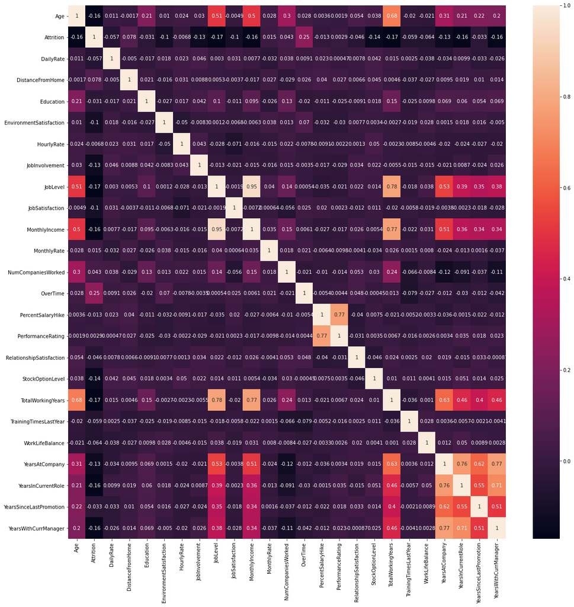

```python
correlations = employee_df.corr()
f,ax = plt.subplots(figsize = (20,20))
sns.heatmap(correlations,annot = True)
```

We found that,

- MonthlyIncome has a strong correlattion to jobLevel.
- TotalWorkoingYears is high correrated to Age, Joblevel and MonthlyInocome.
- Job level is strongly correlated with total working hours
- Monthly income is strongly correlated with total working hours
- Age is stongly correlated with monthly income.

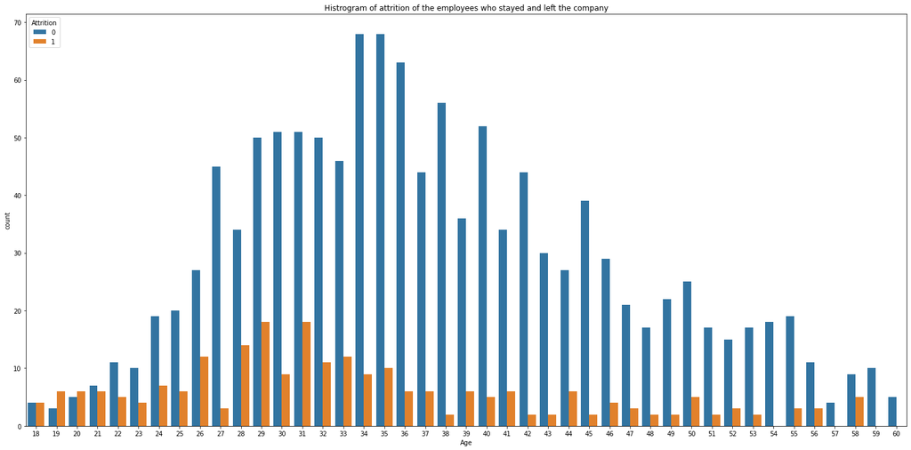

```python
plt.figure(figsize = [25,12])
sns.countplot(x='Age', hue = 'Attrition', data = employee_df)
plt.title('Histrogram of attrition of the employees who stayed and left the company')
```

29 year old employees are most likely to leave the company.

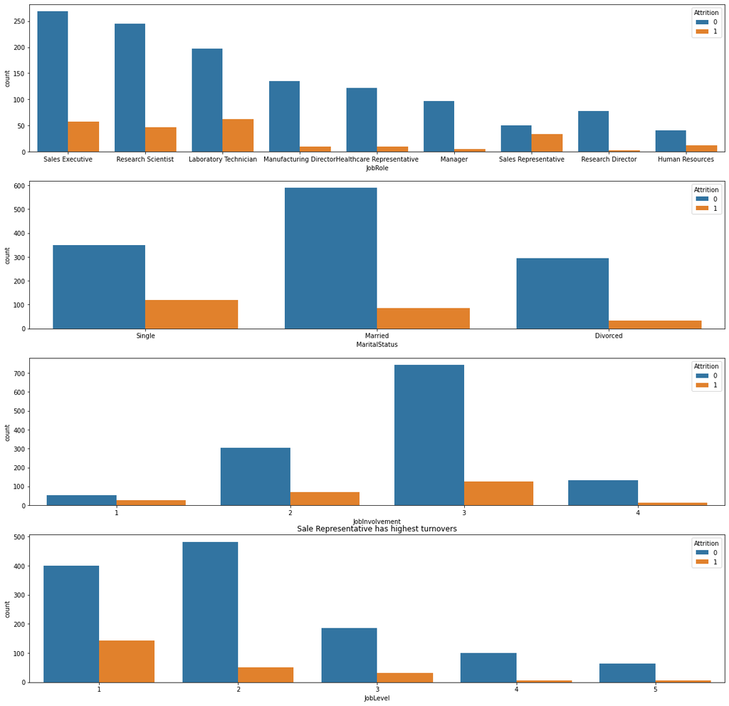

```python
plt.figure(figsize = [20,20])

plt.subplot(411)
sns.countplot( x ='JobRole', hue = 'Attrition', data =employee_df)

plt.subplot(412)
sns.countplot( x ='MaritalStatus', hue = 'Attrition', data =employee_df)

plt.subplot(413)
sns.countplot( x ='JobInvolvement', hue = 'Attrition', data =employee_df)

plt.subplot(414)
sns.countplot( x ='JobLevel', hue = 'Attrition', data =employee_df)

plt.title('Sale Representative has highest turnovers')
```

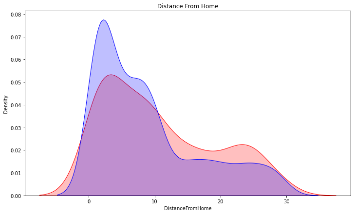

```python
# KDE (Kernel Density Estimate) is used for visualizing the Probability Density of a continuous variable.
# KDE describes the probability density at different values in a continuous variable.
plt.figure(figsize =(12,7))

sns.kdeplot(left_df['DistanceFromHome'], label = 'Employees who left', shade= True, color = 'r')
sns.kdeplot(stayed_df['DistanceFromHome'], label = 'Employees who stayed', shade= True, color = 'b')

plt.title('Distance From Home')
```

Employees who left the company lived far away from work place when compared to those who stayed.

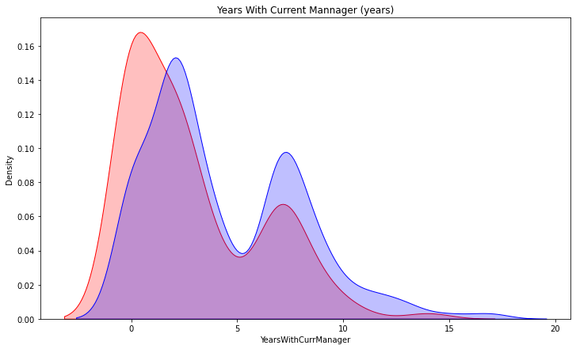

```python
plt.figure(figsize =(12,7))

sns.kdeplot(left_df['YearsWithCurrManager'], label = 'Employees who left', shade= True, color = 'r')
sns.kdeplot(stayed_df['YearsWithCurrManager'], label = 'Employees who stayed', shade= True, color = 'b')

plt.title('Years With Current Mannager (years)')
```

Employees who has less than 5 year working with the current manager tend to leave the company more when comaperd to others.

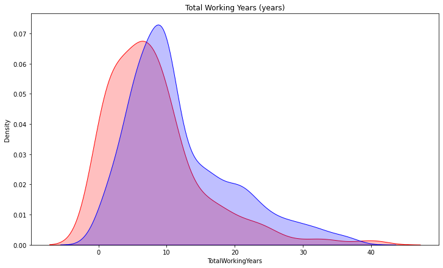

```python
plt.figure(figsize =(12,7))

sns.kdeplot(left_df['TotalWorkingYears'], label = 'Employees who left', shade= True, color = 'r')
sns.kdeplot(stayed_df['TotalWorkingYears'], label = 'Employees who left', shade= True, color = 'b')

plt.title('Total Working Years (years)')
```

Employees who has about 5 year working tend to leave the company more when comaperd to others.

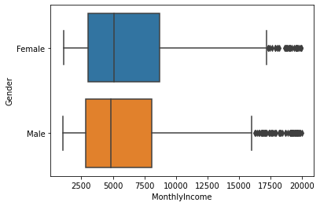

```python
# Let's see the Gender vs. Monthly Income
sns.boxplot(x ='MonthlyIncome', y ='Gender', data = employee_df)
```

The median income of females which is around $5,000 is higher than that of males.

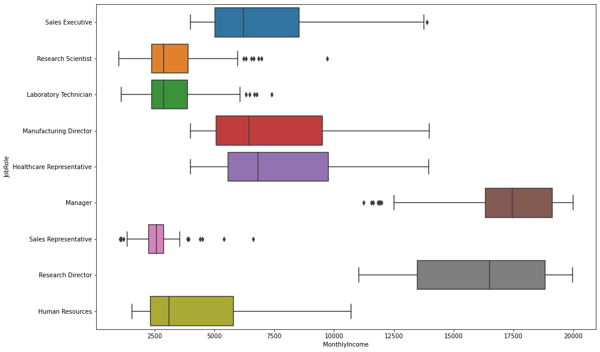

```python
# Let's see the Gender vs. Monthly Income
plt.figure(figsize = (15,10))
sns.boxplot(x ='MonthlyIncome', y ='JobRole', data = employee_df)
```

- Managers tend to earn more salary when compared to others which is about $17,500.
- Sales representatives tend to earn less salary when compared to others which is about $2,500.

### Modeling

```python
employee_df.head(5)
```

|  | Age | Attrition | BusinessTravel | DailyRate | Department | DistanceFromHome | Education | EducationField | EnvironmentSatisfaction | Gender | ... | PerformanceRating | RelationshipSatisfaction | StockOptionLevel | TotalWorkingYears | TrainingTimesLastYear | WorkLifeBalance | YearsAtCompany | YearsInCurrentRole | YearsSinceLastPromotion | YearsWithCurrManager |
| --- | --- | --- | --- | --- | --- | --- | --- | --- | --- | --- | --- | --- | --- | --- | --- | --- | --- | --- | --- | --- | --- |
| 0 | 41 | 1 | Travel_Rarely | 1102 | Sales | 1 | 2 | Life Sciences | 2 | Female | ... | 3 | 1 | 0 | 8 | 0 | 1 | 6 | 4 | 0 | 5 |
| 1 | 49 | 0 | Travel_Frequently | 279 | Research & Development | 8 | 1 | Life Sciences | 3 | Male | ... | 4 | 4 | 1 | 10 | 3 | 3 | 10 | 7 | 1 | 7 |
| 2 | 37 | 1 | Travel_Rarely | 1373 | Research & Development | 2 | 2 | Other | 4 | Male | ... | 3 | 2 | 0 | 7 | 3 | 3 | 0 | 0 | 0 | 0 |
| 3 | 33 | 0 | Travel_Frequently | 1392 | Research & Development | 3 | 4 | Life Sciences | 4 | Female | ... | 3 | 3 | 0 | 8 | 3 | 3 | 8 | 7 | 3 | 0 |
| 4 | 27 | 0 | Travel_Rarely | 591 | Research & Development | 2 | 1 | Medical | 1 | Male | ... | 3 | 4 | 1 | 6 | 3 | 3 | 2 | 2 | 2 | 2 |

5 rows × 31 columns

```python
employee_df.info()
```

```
<class 'pandas.core.frame.DataFrame'>
RangeIndex: 1470 entries, 0 to 1469
Data columns (total 31 columns):
 #   Column                    Non-Null Count  Dtype
---  ------                    --------------  -----
 0   Age                       1470 non-null   int64
 1   Attrition                 1470 non-null   int64
 2   BusinessTravel            1470 non-null   object
 3   DailyRate                 1470 non-null   int64
 4   Department                1470 non-null   object
 5   DistanceFromHome          1470 non-null   int64
 6   Education                 1470 non-null   int64
 7   EducationField            1470 non-null   object
 8   EnvironmentSatisfaction   1470 non-null   int64
 9   Gender                    1470 non-null   object
```

[output cut: 23 more lines]

```python
## categorical values
cate_df = employee_df[['BusinessTravel','Department','EducationField','Gender','JobRole','MaritalStatus']]
cate_df.head()
```

|  | BusinessTravel | Department | EducationField | Gender | JobRole | MaritalStatus |
| --- | --- | --- | --- | --- | --- | --- |
| 0 | Travel_Rarely | Sales | Life Sciences | Female | Sales Executive | Single |
| 1 | Travel_Frequently | Research & Development | Life Sciences | Male | Research Scientist | Married |
| 2 | Travel_Rarely | Research & Development | Other | Male | Laboratory Technician | Single |
| 3 | Travel_Frequently | Research & Development | Life Sciences | Female | Research Scientist | Married |
| 4 | Travel_Rarely | Research & Development | Medical | Male | Laboratory Technician | Married |

```python
## changing categorical to numerical values usind sklearn
from sklearn.preprocessing import OneHotEncoder
onehotencoder = OneHotEncoder()
cate_df = onehotencoder.fit_transform(cate_df).toarray()
```

```python
cate_df.shape
```

```
(1470, 26)
```

```python
## put an array the info to a dataframe
cate_df = pd.DataFrame(cate_df)
```

```python
cate_df.head()
```

|  | 0 | 1 | 2 | 3 | 4 | 5 | 6 | 7 | 8 | 9 | ... | 16 | 17 | 18 | 19 | 20 | 21 | 22 | 23 | 24 | 25 |
| --- | --- | --- | --- | --- | --- | --- | --- | --- | --- | --- | --- | --- | --- | --- | --- | --- | --- | --- | --- | --- | --- |
| 0 | 0.0 | 0.0 | 1.0 | 0.0 | 0.0 | 1.0 | 0.0 | 1.0 | 0.0 | 0.0 | ... | 0.0 | 0.0 | 0.0 | 0.0 | 0.0 | 1.0 | 0.0 | 0.0 | 0.0 | 1.0 |
| 1 | 0.0 | 1.0 | 0.0 | 0.0 | 1.0 | 0.0 | 0.0 | 1.0 | 0.0 | 0.0 | ... | 0.0 | 0.0 | 0.0 | 0.0 | 1.0 | 0.0 | 0.0 | 0.0 | 1.0 | 0.0 |
| 2 | 0.0 | 0.0 | 1.0 | 0.0 | 1.0 | 0.0 | 0.0 | 0.0 | 0.0 | 0.0 | ... | 1.0 | 0.0 | 0.0 | 0.0 | 0.0 | 0.0 | 0.0 | 0.0 | 0.0 | 1.0 |
| 3 | 0.0 | 1.0 | 0.0 | 0.0 | 1.0 | 0.0 | 0.0 | 1.0 | 0.0 | 0.0 | ... | 0.0 | 0.0 | 0.0 | 0.0 | 1.0 | 0.0 | 0.0 | 0.0 | 1.0 | 0.0 |
| 4 | 0.0 | 0.0 | 1.0 | 0.0 | 1.0 | 0.0 | 0.0 | 0.0 | 0.0 | 1.0 | ... | 1.0 | 0.0 | 0.0 | 0.0 | 0.0 | 0.0 | 0.0 | 0.0 | 1.0 | 0.0 |

5 rows × 26 columns

```python
# note that we dropped the target 'Atrittion'as a predicted label and others which don't make any sense for predictors.
numerical_df = employee_df.drop(['Attrition','BusinessTravel','Department','EducationField','Gender','JobRole','MaritalStatus'], axis =1)
numerical_df
```

|  | Age | DailyRate | DistanceFromHome | Education | EnvironmentSatisfaction | HourlyRate | JobInvolvement | JobLevel | JobSatisfaction | MonthlyIncome | ... | PerformanceRating | RelationshipSatisfaction | StockOptionLevel | TotalWorkingYears | TrainingTimesLastYear | WorkLifeBalance | YearsAtCompany | YearsInCurrentRole | YearsSinceLastPromotion | YearsWithCurrManager |
| --- | --- | --- | --- | --- | --- | --- | --- | --- | --- | --- | --- | --- | --- | --- | --- | --- | --- | --- | --- | --- | --- |
| 0 | 41 | 1102 | 1 | 2 | 2 | 94 | 3 | 2 | 4 | 5993 | ... | 3 | 1 | 0 | 8 | 0 | 1 | 6 | 4 | 0 | 5 |
| 1 | 49 | 279 | 8 | 1 | 3 | 61 | 2 | 2 | 2 | 5130 | ... | 4 | 4 | 1 | 10 | 3 | 3 | 10 | 7 | 1 | 7 |
| 2 | 37 | 1373 | 2 | 2 | 4 | 92 | 2 | 1 | 3 | 2090 | ... | 3 | 2 | 0 | 7 | 3 | 3 | 0 | 0 | 0 | 0 |
| 3 | 33 | 1392 | 3 | 4 | 4 | 56 | 3 | 1 | 3 | 2909 | ... | 3 | 3 | 0 | 8 | 3 | 3 | 8 | 7 | 3 | 0 |
| 4 | 27 | 591 | 2 | 1 | 1 | 40 | 3 | 1 | 2 | 3468 | ... | 3 | 4 | 1 | 6 | 3 | 3 | 2 | 2 | 2 | 2 |
| ... | ... | ... | ... | ... | ... | ... | ... | ... | ... | ... | ... | ... | ... | ... | ... | ... | ... | ... | ... | ... | ... |
| 1465 | 36 | 884 | 23 | 2 | 3 | 41 | 4 | 2 | 4 | 2571 | ... | 3 | 3 | 1 | 17 | 3 | 3 | 5 | 2 | 0 | 3 |
| 1466 | 39 | 613 | 6 | 1 | 4 | 42 | 2 | 3 | 1 | 9991 | ... | 3 | 1 | 1 | 9 | 5 | 3 | 7 | 7 | 1 | 7 |
| 1467 | 27 | 155 | 4 | 3 | 2 | 87 | 4 | 2 | 2 | 6142 | ... | 4 | 2 | 1 | 6 | 0 | 3 | 6 | 2 | 0 | 3 |
| 1468 | 49 | 1023 | 2 | 3 | 4 | 63 | 2 | 2 | 2 | 5390 | ... | 3 | 4 | 0 | 17 | 3 | 2 | 9 | 6 | 0 | 8 |
| 1469 | 34 | 628 | 8 | 3 | 2 | 82 | 4 | 2 | 3 | 4404 | ... | 3 | 1 | 0 | 6 | 3 | 4 | 4 | 3 | 1 | 2 |

1470 rows × 24 columns

```python
## concate 'cate_df' and 'numerical_df' together
combine_df = pd.concat([cate_df, numerical_df], axis = 1)
combine_df.head()
```

|  | 0 | 1 | 2 | 3 | 4 | 5 | 6 | 7 | 8 | 9 | ... | PerformanceRating | RelationshipSatisfaction | StockOptionLevel | TotalWorkingYears | TrainingTimesLastYear | WorkLifeBalance | YearsAtCompany | YearsInCurrentRole | YearsSinceLastPromotion | YearsWithCurrManager |
| --- | --- | --- | --- | --- | --- | --- | --- | --- | --- | --- | --- | --- | --- | --- | --- | --- | --- | --- | --- | --- | --- |
| 0 | 0.0 | 0.0 | 1.0 | 0.0 | 0.0 | 1.0 | 0.0 | 1.0 | 0.0 | 0.0 | ... | 3 | 1 | 0 | 8 | 0 | 1 | 6 | 4 | 0 | 5 |
| 1 | 0.0 | 1.0 | 0.0 | 0.0 | 1.0 | 0.0 | 0.0 | 1.0 | 0.0 | 0.0 | ... | 4 | 4 | 1 | 10 | 3 | 3 | 10 | 7 | 1 | 7 |
| 2 | 0.0 | 0.0 | 1.0 | 0.0 | 1.0 | 0.0 | 0.0 | 0.0 | 0.0 | 0.0 | ... | 3 | 2 | 0 | 7 | 3 | 3 | 0 | 0 | 0 | 0 |
| 3 | 0.0 | 1.0 | 0.0 | 0.0 | 1.0 | 0.0 | 0.0 | 1.0 | 0.0 | 0.0 | ... | 3 | 3 | 0 | 8 | 3 | 3 | 8 | 7 | 3 | 0 |
| 4 | 0.0 | 0.0 | 1.0 | 0.0 | 1.0 | 0.0 | 0.0 | 0.0 | 0.0 | 1.0 | ... | 3 | 4 | 1 | 6 | 3 | 3 | 2 | 2 | 2 | 2 |

5 rows × 50 columns

```python
## normaliza the data by using min-max scaler to treat all features equally
from sklearn.preprocessing import MinMaxScaler
scaler= MinMaxScaler()
X = scaler.fit_transform(combine_df)
X
```

```
array([[0.        , 0.        , 1.        , ..., 0.22222222, 0.        ,
        0.29411765],
       [0.        , 1.        , 0.        , ..., 0.38888889, 0.06666667,
        0.41176471],
       [0.        , 0.        , 1.        , ..., 0.        , 0.        ,
        0.        ],
       ...,
       [0.        , 0.        , 1.        , ..., 0.11111111, 0.        ,
        0.17647059],
       [0.        , 1.        , 0.        , ..., 0.33333333, 0.        ,
        0.47058824],
       [0.        , 0.        , 1.        , ..., 0.16666667, 0.06666667,
        0.11764706]])
```

```python
y = employee_df['Attrition']
y
```

```
0       1
1       0
2       1
3       0
4       0
       ..
1465    0
1466    0
1467    0
1468    0
1469    0
Name: Attrition, Length: 1470, dtype: int64
```

### Implemeting Logistic Regression

```python
from sklearn.model_selection import train_test_split
X_train, X_test, y_train, y_test = train_test_split(X,y, test_size = 0.25)
```

```python
X_train.shape
```

```
(1102, 50)
```

```python
from sklearn.linear_model import LogisticRegression
from sklearn.metrics import accuracy_score

model = LogisticRegression()
model.fit(X_train, y_train) ##

y_pred = model.predict(X_test) ## make a prediction based on training data
```

```python
y_pred
```

```
array([0, 0, 0, 0, 0, 0, 0, 0, 0, 1, 0, 0, 0, 0, 0, 0, 0, 0, 0, 0, 0, 0,
       0, 1, 1, 0, 0, 0, 0, 0, 0, 0, 0, 0, 1, 1, 0, 0, 0, 0, 1, 0, 1, 0,
       0, 0, 0, 0, 0, 0, 0, 0, 0, 0, 0, 0, 0, 0, 0, 0, 0, 0, 0, 0, 0, 0,
       0, 0, 0, 0, 0, 0, 0, 0, 0, 0, 0, 0, 0, 0, 0, 1, 1, 0, 0, 0, 0, 0,
       0, 0, 1, 0, 0, 0, 0, 0, 0, 0, 0, 0, 0, 0, 1, 0, 0, 0, 0, 0, 0, 0,
       0, 0, 0, 0, 0, 0, 1, 0, 0, 0, 0, 0, 0, 0, 1, 0, 0, 0, 0, 0, 0, 0,
       0, 0, 0, 0, 0, 0, 1, 0, 0, 0, 0, 0, 0, 1, 0, 0, 1, 0, 1, 0, 0, 0,
       0, 0, 0, 0, 0, 0, 0, 0, 0, 0, 0, 0, 0, 0, 0, 0, 0, 0, 0, 0, 0, 0,
       0, 0, 0, 0, 0, 0, 0, 0, 0, 0, 0, 0, 0, 0, 0, 0, 0, 0, 0, 0, 0, 1,
       0, 0, 0, 0, 0, 0, 1, 0, 0, 0, 0, 0, 0, 0, 0, 0, 0, 0, 0, 0, 0, 0,
       1, 0, 0, 0, 0, 0, 0, 0, 0, 0, 0, 0, 0, 0, 0, 0, 0, 0, 0, 0, 0, 0,
       0, 0, 0, 0, 0, 0, 0, 0, 0, 0, 0, 0, 0, 0, 0, 0, 0, 0, 0, 0, 0, 0,
       0, 0, 0, 0, 1, 0, 0, 0, 0, 0, 0, 0, 0, 0, 0, 0, 0, 0, 0, 0, 0, 0,
       0, 0, 0, 1, 0, 0, 0, 0, 0, 0, 0, 0, 0, 0, 1, 1, 0, 0, 0, 0, 0, 0,
       0, 1, 0, 0, 0, 0, 0, 0, 1, 0, 0, 0, 1, 0, 0, 0, 1, 0, 0, 0, 1, 0,
       0, 0, 0, 0, 0, 0, 0, 0, 0, 0, 1, 0, 1, 0, 0, 0, 0, 0, 0, 1, 0, 0,
       1, 0, 0, 0, 0, 0, 0, 0, 0, 0, 0, 1, 0, 0, 0, 0])
```

```python
# Testing Set Performance
```

```python
from sklearn.metrics import confusion_matrix, classification_report
print('Accuracy {}%'.format(100* accuracy_score(y_pred, y_test)))
```

```
Accuracy 88.8586956521739%
```

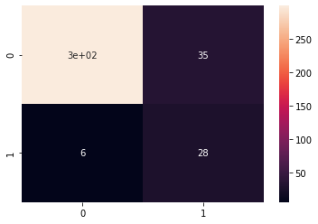

```python
cm = confusion_matrix(y_pred, y_test)
sns.heatmap(cm, annot = True)
```

```python
print(classification_report(y_test, y_pred))
```

```
              precision    recall  f1-score   support

           0       0.90      0.98      0.94       305
           1       0.82      0.44      0.58        63

    accuracy                           0.89       368
   macro avg       0.86      0.71      0.76       368
weighted avg       0.88      0.89      0.87       368
```

- Although the accuraccy rate of the model is great, the recall is not.
- Therefore, the model can not predict 'class 1' well.
- This is because the dataset is imbalance.
- Hence, we have to improve the model by using random forest classifier

### Implementing a random forest classifier.

```python
from sklearn.ensemble import RandomForestClassifier

model = RandomForestClassifier()
model.fit(X_train, y_train)
```

```
RandomForestClassifier()
```

```python
y_pred = model.predict(X_test)
```

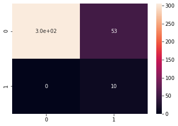

```python
# Testing Set Performance
cm = confusion_matrix(y_pred, y_test)
sns.heatmap(cm, annot=True)
```

```python
print(classification_report(y_test, y_pred))
```

```
              precision    recall  f1-score   support

           0       0.85      1.00      0.92       305
           1       1.00      0.16      0.27        63

    accuracy                           0.86       368
   macro avg       0.93      0.58      0.60       368
weighted avg       0.88      0.86      0.81       368
```

- Recall = 0.2. Therefore, The prediction of class 1 is not good enough to make a prediction of the label 1(left).

### Implementing a deep neuron network model.

```python
import tensorflow as tf

## kera == build the neuron network
## tensorflow works with AI
```

```python
model = tf.keras.models.Sequential()
model.add(tf.keras.layers.Dense(units=500, activation='relu', input_shape=(50, )))
model.add(tf.keras.layers.Dense(units=500, activation='relu')) ## hidden layer
model.add(tf.keras.layers.Dense(units=500, activation='relu')) ## hidden layer
model.add(tf.keras.layers.Dense(units=1, activation='sigmoid')) ## sigmiod fn (0,1)
## relu == activation fn

#None,54
```

```python
model.summary()
```

```
Model: "sequential_6"
_________________________________________________________________
Layer (type)                 Output Shape              Param #
=================================================================
dense_24 (Dense)             (None, 500)               25500
_________________________________________________________________
dense_25 (Dense)             (None, 500)               250500
_________________________________________________________________
dense_26 (Dense)             (None, 500)               250500
_________________________________________________________________
dense_27 (Dense)             (None, 1)                 501
=================================================================
Total params: 527,001
Trainable params: 527,001
Non-trainable params: 0
_________________________________________________________________
```

```python
model.compile(optimizer='Adam', loss='binary_crossentropy', metrics = ['accuracy'])
```

```python
X_train.shape
```

```
(1102, 50)
```

```python
y_train.shape
```

```
(1102,)
```

```python
epochs_hist = model.fit(X_train, y_train, epochs = 100, batch_size = 50)
```

- oversampler = SMOTE(random_state=0)
- smote_train, smote_target = oversampler.fit_sample(X_train, y_train)
- epochs_hist = model.fit(smote_train, smote_target, epochs = 100, batch_size = 50)

```python
y_pred = model.predict(X_test)
y_pred = (y_pred > 0.5) ## set the threshold
y_pred
```

```
array([[ True],
       [False],
       [False],
       [False],
       [False],
       [False],
       [False],
       [ True],
       [False],
       [False],
       [False],
       [False],
       [False],
       [False],
       [False],
       [False],
       [False],
       [False],
       [False],
       [False],
       [False],
       [False],
       [False],
       [False],
       [ True],
       [False],
       [False],
       [False],
       [False],
       [False],
       [False],
       [False],
       [False],
       [ True],
       [ True],
       [ True],
       [False],
       [False],
       [False],
       [False],
```

[output cut: 313 more lines]

```
       [False],
       [False],
       [False],
       [False],
       [False],
       [False],
       [False],
       [False],
       [ True],
       [False],
       [ True],
       [False],
       [False],
       [False],
       [False]])
```

```python
epochs_hist.history.keys()
```

```
dict_keys(['loss', 'accuracy'])
```

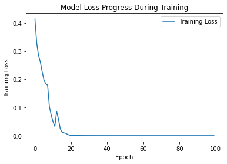

```python
plt.plot(epochs_hist.history['loss'])
plt.title('Model Loss Progress During Training')
plt.xlabel('Epoch')
plt.ylabel('Training Loss')
plt.legend(['Training Loss'])
```

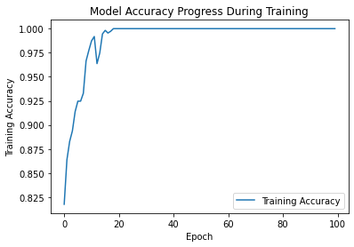

```python
plt.plot(epochs_hist.history['accuracy'])
plt.title('Model Accuracy Progress During Training')
plt.xlabel('Epoch')
plt.ylabel('Training Accuracy')
plt.legend(['Training Accuracy'])
```

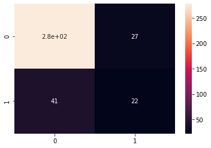

```python
# Testing Set Performance
cm = confusion_matrix(y_test, y_pred)
sns.heatmap(cm, annot = True)
```

```python
print(classification_report(y_test, y_pred))
```

```
              precision    recall  f1-score   support

           0       0.87      0.91      0.89       305
           1       0.45      0.35      0.39        63

    accuracy                           0.82       368
   macro avg       0.66      0.63      0.64       368
weighted avg       0.80      0.82      0.81       368
```